# K-Means Clustering

Fatima Azzahra - G1401231036

2025-11-11

# Studi Kasus

Permasalahan stunting di Indonesia masih menjadi isu strategis nasional, karena berkaitan langsung dengan kualitas sumber daya manusia di masa depan. Beberapa faktor penting yang memengaruhi status gizi balita antara lain pemberian ASI eksklusif dan cakupan imunisasi lengkap.

ASI eksklusif memberikan asupan nutrisi optimal bagi bayi hingga usia 6 bulan, sementara imunisasi berperan dalam mencegah penyakit infeksi yang dapat berimplikasi pada kekurangan gizi kronis.

Dalam upaya memahami pola perilaku dan kondisi kesehatan anak di berbagai provinsi, digunakan metode K-Means Clustering guna mengelompokkan 38 provinsi di Indonesia berdasarkan:

1. Prevalensi balita stunting (%)
2. Persentase pemberian ASI eksklusif (%)
3. Persentase imunisasi lengkap (%)

Analisis ini bertujuan untuk:

- Mengelompokkan provinsi di Indonesia menjadi beberapa klaster dengan karakteristik yang mirip berdasarkan tiga indikator gizi dan kesehatan anak.
- Mengidentifikasi pola dan tingkat pencapaian kesehatan anak di tiap kelompok provinsi.
- Memberikan informasi awal bagi pengambil kebijakan untuk menentukan prioritas intervensi.

# 1. Penyiapan Dataset

Sumber data : BPS  
Deskripsi :  
Dataset berisi prevalensi balita stunting, persentasi pemberian imunisasi lengkap pada anak 12-23 bulan dan persentase pemberian asi eksklusif pada bayi usia kurang dari 6 bulan di 38 provinsi di Indonesia pada tahun 2023.

```r
# Gabung menjadi satu dataset
library(readxl)
stunting <- read_xlsx("D:\\DA_PORTO\\EXCEL\\stunting_prov_23.xlsx")
asi <- read_xlsx("D:\\DA_PORTO\\EXCEL\\asi_prov_23.xlsx")
imunisasi <- read_xlsx("D:\\DA_PORTO\\EXCEL\\imunisasi_prov_23.xlsx")

library(dplyr)
df <- stunting %>%
  inner_join(asi, by = "nama_prov") %>%
  inner_join(imunisasi, by = "nama_prov")
```

```r
View(df)
df
```

```
## # A tibble: 38 × 6
##       id kode_prov nama_prov       prevalensi_balita_st…¹ presentasi_asi_ekskl…²
##    <dbl>     <dbl> <chr>                            <dbl>                  <dbl>
##  1    69        11 ACEH                              29.4                   67.0
##  2    70        12 SUMATERA UTARA                    18.9                   62.0
##  3    71        13 SUMATERA BARAT                    23.6                   75.8
##  4    72        14 RIAU                              13.6                   71.1
##  5    73        15 JAMBI                             13.5                   74.1
##  6    74        16 SUMATERA SELAT…                   20.3                   75.6
##  7    75        17 BENGKULU                          20.2                   72.4
##  8    76        18 LAMPUNG                           14.9                   76.2
##  9    77        19 KEP. BANGKA BE…                   20.6                   63.3
## 10    78        21 KEP. RIAU                         16.8                   62.9
## # ℹ 28 more rows
## # ℹ abbreviated names: ¹prevalensi_balita_stunting, ²presentasi_asi_eksklusif
## # ℹ 1 more variable: presentase_imunisasi_lengkap <dbl>
```

Dalam analisis ini, karena data resmi tahun 2023 tidak tersedia, nilai untuk Papua Tengah, Papua Selatan, Papua Pegunungan, dan Papua Barat Daya diestimasi dari provinsi induknya, yaitu Papua dan Papua Barat.

```r
str(df)
```

```
## tibble [38 × 6] (S3: tbl_df/tbl/data.frame)
##  $ id                          : num [1:38] 69 70 71 72 73 74 75 76 77 78 ...
##  $ kode_prov                   : num [1:38] 11 12 13 14 15 16 17 18 19 21 ...
##  $ nama_prov                   : chr [1:38] "ACEH" "SUMATERA UTARA" "SUMATERA BARAT" "RIAU" ...
##  $ prevalensi_balita_stunting  : num [1:38] 29.4 18.9 23.6 13.6 13.5 20.3 20.2 14.9 20.6 16.8 ...
##  $ presentasi_asi_eksklusif    : num [1:38] 67 62 75.8 71.1 74.1 ...
##  $ presentase_imunisasi_lengkap: num [1:38] 24.8 41 39.1 45 53 ...
```

```r
# Cek missing value
df %>% filter(if_any(everything(), is.na))
```

```
## # A tibble: 0 × 6
## # ℹ 6 variables: id <dbl>, kode_prov <dbl>, nama_prov <chr>,
## #   prevalensi_balita_stunting <dbl>, presentasi_asi_eksklusif <dbl>,
## #   presentase_imunisasi_lengkap <dbl>
```

Dataset memiliki kolom-kolom dengan format yang tepat dan tidak mengandung missing value maupun duplikat sehingga siap untuk dianalisis.

# 2. Prosedur K-Means Clustering

```r
# Scale data
df1 <- df[4:6]
df1_scale <- scale(df1)
```

```r
head(df1_scale)
```

```
##      prevalensi_balita_stunting presentasi_asi_eksklusif
## [1,]                0.857239529               -0.2358430
## [2,]               -0.685559623               -0.8406284
## [3,]                0.005026664                0.8126901
## [4,]               -1.464305862                0.2520410
## [5,]               -1.478999188                0.6099021
## [6,]               -0.479853070                0.7828683
##      presentase_imunisasi_lengkap
## [1,]                   -2.4974738
## [2,]                   -1.3680200
## [3,]                   -1.5014693
## [4,]                   -1.0906957
## [5,]                   -0.5374371
## [6,]                   -0.4463857
```

Meskipun ketiga variabel memiliki satuan yang sama (persentase), scaling tetap dilakukan karena masing-masing variabel memiliki rentang dan variasi yang berbeda. Scaling (standarisasi z-score) memastikan setiap variabel memberikan kontribusi yang seimbang dalam pembentukan klaster.

```r
library(factoextra)
```

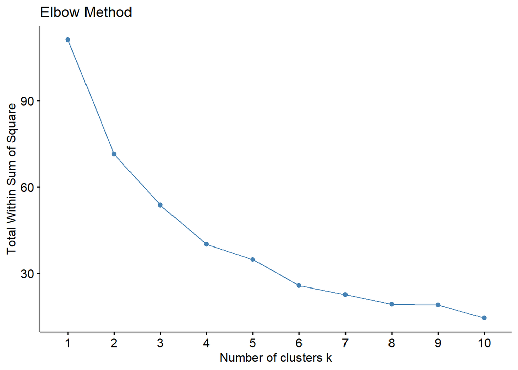

```r
fviz_nbclust(df1_scale, kmeans, method = "wss") + labs(title = "Elbow Method")
```

Metode Elbow (WSS) melihat penurunan *within-cluster sum of squares*, dimana semakin kecil nilainya, maka klaster semakin homogen.

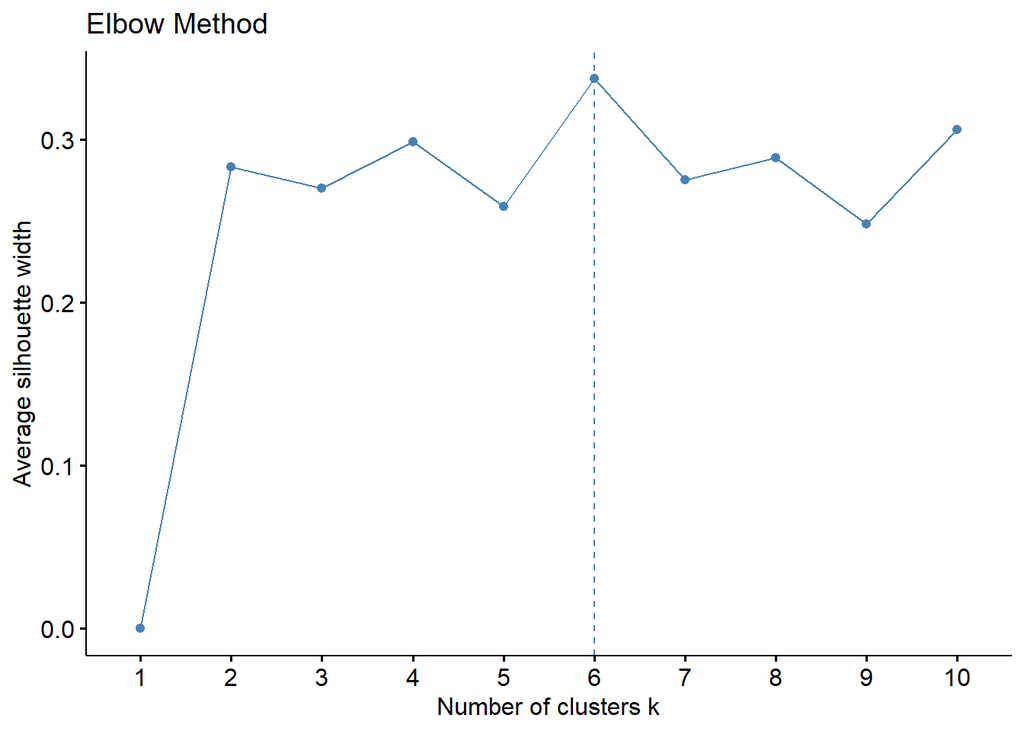

```r
fviz_nbclust(df1_scale, kmeans, method = "silhouette") + labs(title = "Elbow Method")
```

Metode Silhouette menilai kualitas pemisahan antar klaster.

Walaupun hasil optimal menunjukkan k = 6, pemilihan k = 4 dilakukan dengan pertimbangan:

```r
set.seed(123)
for (n in c(5, 10, 20, 50)) {
  hasil <- kmeans(df1_scale, centers = 4, nstart = n)
  cat("nstart =", n, " → total withinss:", hasil$tot.withinss, "\n")
}
```

```
## nstart = 5  → total withinss: 40.035
## nstart = 10  → total withinss: 40.035
## nstart = 20  → total withinss: 40.035
## nstart = 50  → total withinss: 40.035
```

`nstart` digunakan agar algoritma K-Means dijalankan beberapa kali dengan posisi awal centroid berbeda, lalu diambil hasil terbaik (minimum *within-cluster variation*).

Nilai `nstart = 5` sudah cukup untuk dataset kecil seperti ini (38 observasi).

```r
hasil.km <- kmeans(df1_scale, centers = 4, nstart = 5)
hasil.km
```

```
## K-means clustering with 4 clusters of sizes 3, 11, 13, 11
##
## Cluster means:
##   prevalensi_balita_stunting presentasi_asi_eksklusif
## 1                  1.7339413               -1.1615105
## 2                 -1.0902939                0.5621873
## 3                  0.2774183               -0.9471609
## 4                  0.2895429                0.8739602
##   presentase_imunisasi_lengkap
## 1                  -2.23451376
## 2                   0.62019774
## 3                   0.06714815
## 4                  -0.09014180
##
## Clustering vector:
##  [1] 1 3 4 2 2 4 2 2 3 2 2 4 2 2 2 4 2 4 4 4 3 3 4 2 3 3 4 3 3 4 3 4 3 3 3 3 1 1
##
## Within cluster sum of squares by cluster:
## [1]  2.590154 13.006334 12.326979 12.111530
##  (between_SS / total_SS =  63.9 %)
##
## Available components:
##
## [1] "cluster"      "centers"      "totss"        "withinss"     "tot.withinss"
## [6] "betweenss"    "size"         "iter"         "ifault"
```

Pemisahan 4 klaster menjelaskan 63,9% variasi data (cukup baik). Adapun interpretasi dari hasil `cluster means` sebagai berikut,

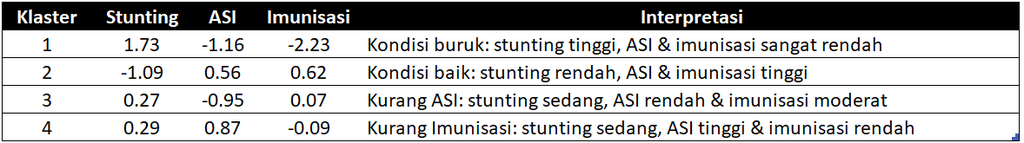

# 3. Visualisasi dan Kesimpulan

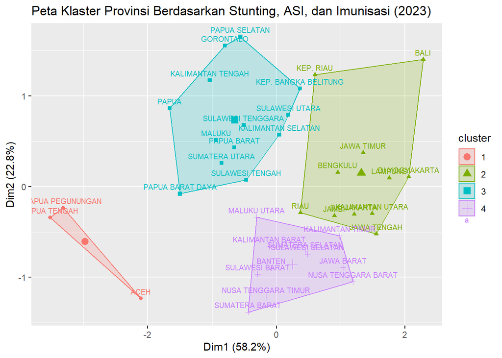

```r
klaster.km <- hasil.km$cluster
rownames(df1_scale) <- paste(df$nama_prov)
fviz_cluster(
  list(data = df1_scale, cluster = klaster.km),
  main = "Peta Klaster Provinsi Berdasarkan Stunting, ASI, dan Imunisasi (2023)",
  labelsize = 8
)
```

```r
library(sf)
prov.shp <- st_read("D:\\DA_PORTO\\batas prov_lapakgis\\LapakGIS_Batas_Provinsi_2024.shp")
head(prov.shp)
```

```
## Simple feature collection with 6 features and 4 fields
## Geometry type: MULTIPOLYGON
## Dimension:     XY
## Bounding box:  xmin: 94.97191 ymin: -4.924159 xmax: 106.2207 ymax: 6.076832
## Geodetic CRS:  WGS 84
##   KDPPUM           WADMPR                                METADATA
## 1     11             Aceh TASWIL1000020230928_DATA_BATAS_PROVINSI
## 2     12   Sumatera Utara TASWIL1000020230928_DATA_BATAS_PROVINSI
## 3     13   Sumatera Barat TASWIL1000020230928_DATA_BATAS_PROVINSI
## 4     14             Riau TASWIL1000020230928_DATA_BATAS_PROVINSI
## 5     15            Jambi TASWIL1000020230928_DATA_BATAS_PROVINSI
## 6     16 Sumatera Selatan TASWIL1000020230928_DATA_BATAS_PROVINSI
##            UPDATED                       geometry
## 1 Lapak GIS - 2024 MULTIPOLYGON (((97.38631 1....
## 2 Lapak GIS - 2024 MULTIPOLYGON (((98.51629 -0...
## 3 Lapak GIS - 2024 MULTIPOLYGON (((100.7819 -3...
## 4 Lapak GIS - 2024 MULTIPOLYGON (((103.5003 -0...
## 5 Lapak GIS - 2024 MULTIPOLYGON (((104.4988 -1...
## 6 Lapak GIS - 2024 MULTIPOLYGON (((106.2155 -3...
```

```r
View(st_drop_geometry(prov.shp))
```

```r
prov.shp <- prov.shp %>%
  mutate(
    KDPPUM = case_when(
      KDPPUM == "91" ~ "94",
      KDPPUM == "93" ~ "95",
      KDPPUM == "94" ~ "96",
      KDPPUM == "95" ~ "97",
      TRUE ~ KDPPUM
    )
  )
```

```r
prov.shp <- prov.shp %>%
  mutate(
    KDPPUM = if_else(KDPPUM == "92" & WADMPR == "Papua Barat", "91", KDPPUM)
  )
```

```r
# Gabungkan data klaster ke shapefile
df1_comp <- prov.shp %>%
  left_join(
    df %>%
      mutate(
        kode_prov = as.character(kode_prov),
        cluster = hasil.km$cluster
      ),
    by = c("KDPPUM" = "kode_prov")
  )
```

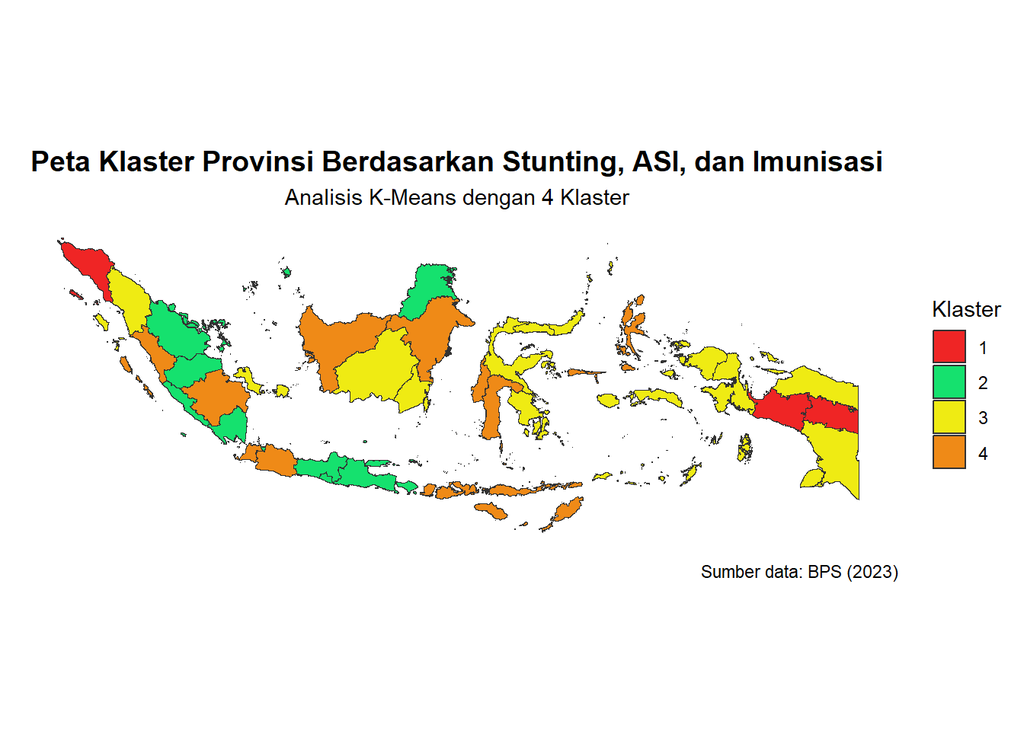

```r
# Plot choropleth final
ggplot(df1_comp) +
  geom_sf(aes(fill = as.factor(cluster)), color = "grey20", size = 0.1) +
  scale_fill_manual(
    values = c(
      "1" = "#EF2525",  # Klaster 1 - merah
      "2" = "#15E16E",  # Klaster 2 - hijau
      "3" = "#EFEB13",  # Klaster 3 - kuning
      "4" = "#EF8A17"   # Klaster 4 - oranye
    ),
    name = "Klaster"
  ) +
  labs(
    title = "Peta Klaster Provinsi Berdasarkan Stunting, ASI, dan Imunisasi",
    subtitle = "Analisis K-Means dengan 4 Klaster",
    caption = "Sumber data: BPS (2023)"
  ) +
  theme_minimal() +
  theme(
    panel.grid = element_blank(),             # hilangkan grid
    plot.title = element_text(face = "bold", size = 14, hjust = 0.5),
    plot.subtitle = element_text(size = 11, hjust = 0.5),
    legend.position = "right",
    axis.text = element_blank(),
    axis.ticks = element_blank(),
    panel.background = element_blank()
  )
```

Berdasarkan interpretasi `cluester means`:

Klaster 1: Kondisi buruk: stunting tinggi, ASI & imunisasi sangat rendah  
Klaster 2: Kondisi baik: stunting rendah, ASI & imunisasi tinggi  
Klaster 3: Kurang ASI: stunting sedang, ASI rendah & imunisasi moderat  
Klaster 4: Kurang Imunisasi: stunting sedang, ASI tinggi & imunisasi rendah

Berikut informasi provinsi dengan klasternya.

```r
df1_comp %>%
  st_drop_geometry() %>%
  select(WADMPR, cluster)
```

```
##                        WADMPR cluster
## 1                        Aceh       1
## 2              Sumatera Utara       3
## 3              Sumatera Barat       4
## 4                        Riau       2
## 5                       Jambi       2
## 6            Sumatera Selatan       4
## 7                    Bengkulu       2
## 8                     Lampung       2
## 9   Kepulauan Bangka Belitung       3
## 10             Kepulauan Riau       2
## 11                DKI Jakarta       2
## 12                 Jawa Barat       4
## 13                Jawa Tengah       2
## 14 Daerah Istimewa Yogyakarta       2
```

[output cut: 24 more lines]

Berdasarkan informasi klaster yang didapat, metode intervensi untuk tiap provinsi bisa disesuaikan dengan klasternya seperti berikut ini:

- Provinsi yang termasuk Klaster 1 membutuhkan intervensi gizi yang intensif, program penyuluhan ASI eksklusif, serta percepatan cakupan imunisasi lengkap.
- Provinsi dalam Klaster 2 dapat dipertahankan melalui program pemeliharaan dan penguatan keberhasilan.
- Provinsi di Klaster 3 sebaiknya difokuskan pada promosi dan dukungan pemberian ASI, disertai pemantauan stunting dan imunisasi moderat agar risiko stunting tidak meningkat.
- Provinsi di Klaster 4 memerlukan peningkatan layanan imunisasi.